# Desmatamento na Amazônia - Análise de dados do Imazon

Sérgio Costa

2019-09-14

## Introdução

Recentemente os principais jornais do Brasil e do Mundo noticiaram um possível aumento nas taxas de desmatamento na Amazônia, a partir de dados divulgados pelo INPE (Instituto Nacional de Pesquisas Espaciais). O tema gerou polêmicas envolvendo o atual presidente Jair Bolsonaro, o Ministro do Meio Ambiente Ricardo Salles e o agora ex-diretor do órgão, Ricardo Galvão - os governistas questionaram a veracidade das informações, incendiando a discussão que culminou na demissão de Galvão.  
Não somente o INPE, mas outras insituições que monitoram a perda de cobertura vegetal na Amazônia brasileira dispararam alertas para a elevação nas taxas de desmatamento, como a Imazon e a Nasa, e a discussão em torno do assunto prosseguiu para além do território brasileiro.

### O embate entre o INPE e o Governo Federal

Os dados divulgados no início de agosto pelo INPE a partir do sistema DETER indicou que a área desmatada na Amazônia brasileira teve um aumento de 278% em relação a julho de 2018, somando 2.254 km² [1]. Considerando o acumulado no período de agosto de 2018 a julho de 2019 os alertas indicaram um aumento de 50% em relação ao mesmo período do ano anterior (agosto de 2017 a julho de 2018). Além da alta no desmatamento o INPE também apontou um aumento expressivo nos focos de incêndio na região e como desmatamento e queimada estão fortemente relacionados [2], o aumento no número de focos de incêndio têm acompanhado o aumento dos alertas de desmatamento [3]. Após a fivulgação dos dados, o presidente Jair Bolsonaro acusou o Inpe de divulgar dados que não condiziam com a realidade [4] e Ricardo Salles atribuiu o aumento dos incêndios à ocorrência de tempo seco, vento e calor na região [5].

### A busca pelos dados

Como aqui busco defender o conceito de análise replicável, fui em busca dos dados originais disponibilizados pelo INPE para gerar minhas próprias análises e interpretações sobre o tema, já que assunto tomou as redes sociais, que ficaram repletas de informações distorcidas [2]. Apesar do *dashboard* disponível na plataforma [TerraBrasilis](http://terrabrasilis.dpi.inpe.br/) permitir visualização e análise dos dados do Deter, estes são disponibilizados apenas para o período de 1 ano, o que impede que possamos comparar os dados recentes com os obtidos em anos anteriores.

### O Sistema de Alerta de Desmatamento do Imazon

O Imazon é uma instituição de pesquisas sem fins lucrativos, qualificada pelo Ministério da Justiça, e que realiza o monitoramento da Amazônia Legal pelo uso de imagens de satélites que reportam mensalmente o ritmo do desmatamento e da degradação florestal na região por meio do Sistema de Alerta de Desmatamento (SAD). No site do [ImazonGeo](https://imazongeo.org.br/#/) estão disponíveis os dados mensais de desmatamento e degradação florestal desde janeiro de 2008. É importante salientar que o SAD somente detecta áreas de desmatamento superiores a 1 hectare e que apesar de ambos monitorarem o desmatamento na Amazônia, os dados do SAD não são comparáveis aos do DETER, devido a diferenças metodológicas. As detecções do SAD são realizadas somente para áreas de floresta primária, ou seja, florestas que nunca sofreram perturbações significativas, enquanto o Deter é um sistema de alertas que avalia alterações na cobertura florestal, servindo de suporte para órgãos de fiscalização ambiental. Maiores informações sobre o método empregado pelo SAD pode ser obtidos [aqui](https://imazon.org.br/publicacoes/faq-sad/).

### Obtendo dados climáticos da Amazonia Legal

Para complementar a análise, consolidei dados de estações meteorológicas do Banco de Dados Meteorológicos para Ensino e Pesquisa (BDMEP) do Instituto Nacional de Meteorologia (INMET). O banco abriga dados meteorológicos diários em forma digital, coletados por meio das várias estações meteorológicas convencionais da rede de estações do INMET, de acordo com as normas técnicas internacionais da Organização Meteorológica Mundial [6]. O procedimento de consolidação foi simples: a partir dos dados diários das estações meteorológicas instaladas nos Estados do Acre, Amazonas, Amapá, Pará, Roraima e Rondônia (47 estações) foi obtida a precipitação mensal média para cada mês-ano, considerando os dados de todas as estações. O procedimento de obtenção dos dados pode ser acessado [aqui](https://github.com/sergiocostafh/desmatamento_sad_imazon).

## Analisando os dados do SAD

Os dados de desmatamento disponibilizados pelo SAD estão em formato *shapefile* e foi necessário algum trabalho computacional para compilá-los em uma tabela, já que os arquivos são separados mês a mês. Fiz o download de todos os meses compreendidos entre agosto de 2009 e julho de 2019, totalizando 10 anos de análise ou 120 meses. Isso foi possível graças ao programa R, e todo o procedimento desenvolvido para compilação dos dados em uma única tabela está disponível em meu repositório pessoal no GitHub (clique [aqui](https://github.com/sergiocostafh/desmatamento_sad_imazon/blob/master/tratamento%20de%20dados_imazon.R) para acessar).

Nesta postagem foi possível reproduzir resultados que têm sido publicados na [seção de transparência florestal](https://imazon.org.br/categorias/transparencia-florestal/) no site do Imazon. Todas as análises realizadas podem ser acessadas clicando no botão **código** localizado logo acima dos gráficos, no canto direito.

Vamos então às análises. Mas não sem antes recomendar que você clique **aqui** e entenda por que apresento os scripts de análises ao longo das postagens e a importância das análises replicáveis.

Ao visualizar a série histórica dos dados mensais de desmatamento mapeado pelo SAD, alguns padrões já nos saltam aos olhos. O primeiro que podemos elencar é que o mês de julho de 2019 registrou o maior acúmulo de área desmatada em um mês para toda a série histórica, e isso já explica boa parte da discussão levantada nas últimas semanas. Outro ponto importante é que há uma clara tendência na formação de picos ascendentes na taxa de desmatamento desde 2012.  
Os picos ocorrem geralmente entre os meses de junho e julho, que coincide com o período do ano de menor pluviosidade na região. No entanto, não há alterações visíveis no padrão de chuvas na região ao longo dos 10 anos de análise, indicando inexistência de períodos mais secos na região, e que portanto, não há relação climática com o aumento na quantidade de focos de incêndio detectados pelo INPE.

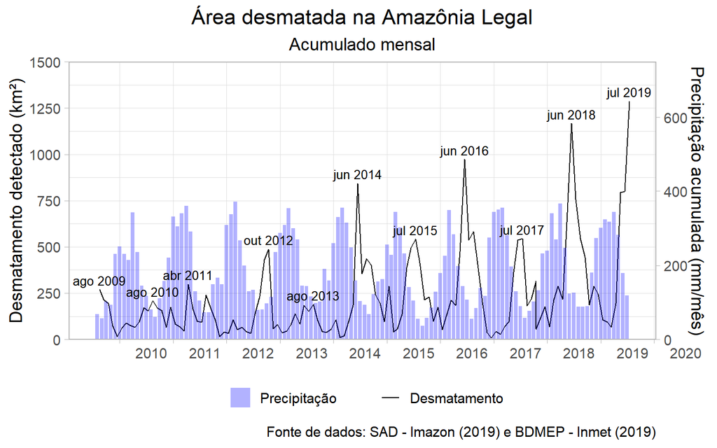

```r
# Importar a base de dados do SAD
dados_desmatamento <- read.table('https://raw.githubusercontent.com/sergiocostafh/desmatamento_sad_imazon/master/dados_sad.txt')
dados_precipitacao <- read.table('https://raw.githubusercontent.com/sergiocostafh/desmatamento_sad_imazon/master/serie_precipitacao_amazonia_inmet.txt')
dados_precipitacao$date <- as.Date(dados_precipitacao$date)
# Criar coluna Mês - Ano
dados_desmatamento$`MES ANO`=as.Date(paste(dados_desmatamento$ANO,'-',dados_desmatamento$MES,'-15', sep=''))
# Carregar pacotes necessário para geração dos gráficos
library(ggplot2)
library(plotly)
# Plotar série histórica de desmatamento mensal
ggplot()+
  geom_line(aes(x=dados_desmatamento$`MES ANO`, y=dados_desmatamento$AREA, color = 'Desmatamento'))+
  geom_bar(aes(x=dados_precipitacao$date, y=dados_precipitacao$prec*2,
            fill = 'Precipitação'),stat = 'identity', alpha = .3, color = NA)+
    scale_x_date(expand = c(0.05,0), breaks = 'year',
                 date_labels = '%Y', minor_breaks = NULL)+
    scale_y_continuous(expand = c(0,0), limits = c(0,1500),
                     breaks = seq(0,1500,250),
                     sec.axis = sec_axis(~./2, name = 'Precipitação acumulada (mm/mês)'))+
  scale_color_manual(name = NULL ,values = c('black'))+
  scale_fill_manual(name = NULL ,values = c('blue'))+
  xlab(NULL)+
  ylab('Desmatamento detectado (km²)')+
  labs(title = 'Área desmatada na Amazônia Legal',
       subtitle = 'Acumulado mensal',
       caption = 'Fonte de dados: SAD - Imazon (2019) e BDMEP - Inmet (2019)')+
  theme_light(base_size = 14)+
  theme(plot.title = element_text(hjust = 0.5),
        plot.subtitle = element_text(hjust = 0.5),
        axis.text.x = element_text(hjust = -0.5),
        legend.position = 'bottom')+
  annotate(geom='text', size = 3.5,
           x=dados_desmatamento$`MES ANO`[c(1,13,21,39,49,59,72,82,95,106,119)],
           y=dados_desmatamento$AREA[c(1,13,21,39,49,59,72,82,95,106,119)]+50,
           label=format.Date(dados_desmatamento$`MES ANO`[c(1,13,21,39,49,59,72,82,95,106,119)],'%b %Y'))
```

```r
# Comparação julho 2019/julho 2018
# round(1-dados_desmatamento$AREA[119]/dados_desmatamento$AREA[107], 3)*-1
# Comparação junho 2019/julho 2018
# round(1-dados_desmatamento$AREA[118]/dados_desmatamento$AREA[106], 3)*-1
```

Se tomarmos por base a área desmatada no mês de julho de 2018 (758 km²) e compararmos ao mesmo mês de 2019 (1.287 km²), constataremos que houve um aumento de 70%. A interpretação deste resultado exige cuidado pois pode gerar interpretações tendenciosas quando avaliado isoladamente. Um exemplo disso, é que se aplicarmos a mesma análise ao mês de junho, em que a área desmatada somou 1167 km² e 801 km² para 2018 e 2019 respectivamente, o resultado será uma redução de 31,4%. O fato é que para podermos interpretar os dados de desmatamento de maneira mais consistente, precisamos avaliar o acúmulo de área desmatada em períodos maiores. O gráfico seguinte apresenta a área total desmatada detectada pelo SAD nos meses de janeiro a julho e a série histórica anual do PRODES e do SAD, desde 2010. Assim como o DETER, os dados do PRODES não devem ser comparados diretamente com os dados do SAD por diferenças metodológicas - o PRODES calcula o desmatamento entre 1º de agosto de um ano 31 de julho do ano seguinte, e considera não somente áreas primárias de vegetação, mas também secundárias [7]. Ainda assim, é possível observar a mesma tendência de elevação no desmatamento a partir de 2012/2013.

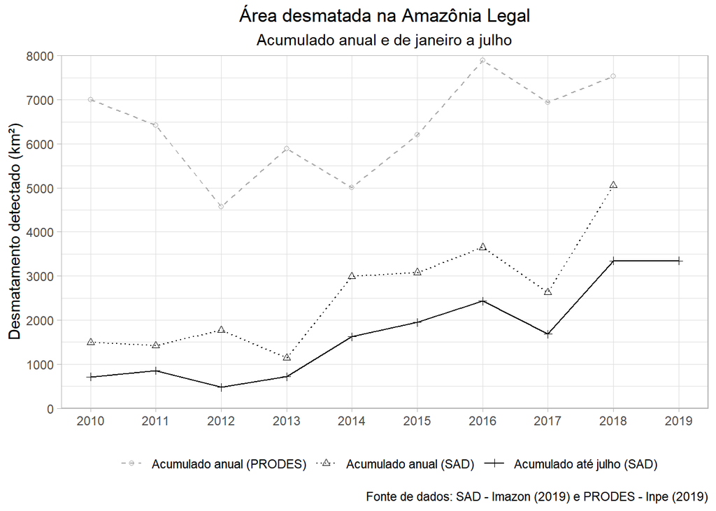

```r
# Calcular área desmatada acumulada até julho
acumulado_julho <- subset(dados_desmatamento,dados_desmatamento$MES<=7)
acumulado_julho <- aggregate(acumulado_julho$AREA, by = list(ANO = as.integer(acumulado_julho$ANO)), sum)
acumulado_ano <- aggregate(dados_desmatamento$AREA, by = list(ANO = as.integer(dados_desmatamento$ANO)), sum)[-c(1,11),]
# Dados do PRODES
dados_prodes <- read.delim('https://raw.githubusercontent.com/sergiocostafh/desmatamento_sad_imazon/master/dados_prodes.txt')
dados_prodes <- subset(dados_prodes,dados_prodes$Ano.Estados>=2010)
# Plotar gráfico
ggplot()+
  geom_line(aes(x=acumulado_ano$ANO,y=acumulado_ano$x, linetype = 'Acumulado anual (SAD)', color = 'Acumulado anual (SAD)'))+
  geom_line(aes(x=acumulado_julho$ANO,y=acumulado_julho$x, linetype = 'Acumulado até julho (SAD)', color = 'Acumulado até julho (SAD)'))+
  geom_line(aes(x=dados_prodes$Ano.Estados,y=dados_prodes$AMZ.LEGAL, linetype = 'Acumulado anual (PRODES)', color = 'Acumulado anual (PRODES)'))+
    geom_point(aes(x=acumulado_ano$ANO,y=acumulado_ano$x, shape = 'Acumulado anual (SAD)', color = 'Acumulado anual (SAD)'))+
  geom_point(aes(x=acumulado_julho$ANO,y=acumulado_julho$x, shape = 'Acumulado até julho (SAD)', color = 'Acumulado até julho (SAD)'))+
  geom_point(aes(x=dados_prodes$Ano.Estados,y=dados_prodes$AMZ.LEGAL, shape = 'Acumulado anual (PRODES)', color = 'Acumulado anual (PRODES)'))+
  scale_x_continuous(breaks=seq(2009,2019,1), minor_breaks = NULL)+
  scale_y_continuous(expand=c(0,0),limits = c(0,8000), breaks = seq(0,8000,1000))+
  scale_linetype_manual(name = NULL, values = c('dashed','dotted','solid'))+
  scale_shape_manual(name = NULL, values = c(1,2,3))+
  scale_color_manual(name = NULL, values = c('darkgray','black','black'))+
  xlab(NULL)+
  ylab('Desmatamento detectado (km²)')+
  labs(title = 'Área desmatada na Amazônia Legal',
       subtitle = 'Acumulado anual e de janeiro a julho',
       caption = 'Fonte de dados: SAD - Imazon (2019) e PRODES - Inpe (2019)')+
  theme_light()+
  theme(plot.title = element_text(hjust = 0.5),
        plot.subtitle = element_text(hjust = 0.5),
        legend.position = 'bottom')
```

Os dados do SAD apontam que em 2018 foi atingida a máxima da série para o acumulado anual, e que em 2019 a área acumulada para o período janeiro-julho se encontra no mesmo patamar de 2018. A partir disso pode-se inferir que em 2019 teremos uma taxa similar a 2018, ou mesmo maior, considerando o expressivo aumento detectado no mês de julho, citado anteriormente.

## Conclusões

A partir das análises realizadas, podemos conluir que:  
**1.** Em julho de 2019 a série de desmatamento detectado pelo Sistema de Alertas de Desmatamento do Imazon alcançou sua máxima histórica, considerando a cobertura vegetal primária perdida no período de um mês.  
**2.** Não há ocorrência de períodos mais secos na Amazônia Legal que justifiquem aumento nos focos de incêndio apontados pelo INPE. **3.** Há uma tendência de aumento nas taxas de desmatamento iniciada após o ano de 2012.  
**4.** As análises sugerem que o acumulado anual de 2019 pode alcançar o mesmo patamar de 2018, ou até mesmo atingir uma nova máixma histórica.

## Referências

[1] http://www.observatoriodoclima.eco.br/desmatamento-subiu-50-em-2019-indicam-alertas-inpe/

[2] https://aosfatos.org/noticias/o-que-realmente-se-sabe-sobre-queimadas-no-brasil/

[3] https://epoca.globo.com/sociedade/dados-do-inpe-do-imazon-mostram-mais-queimadas-em-municipios-com-mais-desmatamento-23897439

[4] https://www.terra.com.br/noticias/ciencia/sustentabilidade/bolsonaro-acusa-inpe-de-divulgar-dados-mentirosos-sobre-desmatamento,41bf3feb7bab7d742c3bbb4f84c62bb74nes2dyy.html

[5] https://oglobo.globo.com/sociedade/ricardo-salles-atribui-aumento-de-queimadas-seca-mas-ipam-diz-que-estiagem-este-ano-foi-menor-23891622

[6] http://www.inmet.gov.br/projetos/rede/pesquisa/

[7] http://www.obt.inpe.br/prodes/metodologia.pdf